# Workshop Week 4

Author

Affiliation

STAT5003

School of Mathematics and Statistics

# 1 Learning Outcomes

**Learning Outcomes**

1. Use `set.seed` to ensure reproducible results in simulations.
2. Use `rnorm`, `rbinom` and `runif` to generate random samples from various probability distributions.
3. Explain and compute **MLE estimators** for different statistical models.
4. Use `density` to perform non-parametric density estimation.
5. Select optimal bandwidth for kernel density estimation based on an accuracy metric.

# 2 Loading Packages

At the start of your R workshop, load all necessary packages to ensure a smooth session. Here’s an example:

```r
library(dplyr)      # Data manipulation
library(tidyr)      # Tidying data
library(tidyverse)  # Data science packages
library(ggplot2)    # Data visualization
library(here)       # File paths
```

# 3 Parametric Density Estimation

**Basic Gaussian Simulation**

Simulate 100 samples of a normal distribution (`rnorm`) with mean of 10 and standard deviation of 10. Plot a histogram of this sample.

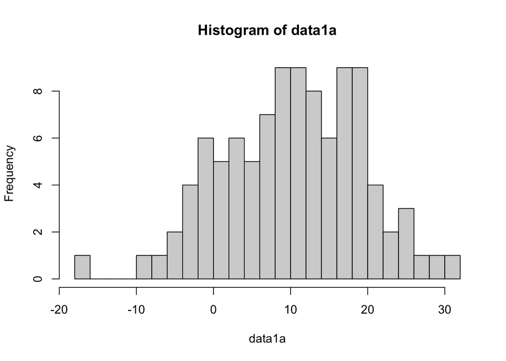

```r
data1a <- rnorm(100, mean = 10, sd = 10)

hist(data1a, breaks = 30)
```

Alternatively, using ggplot

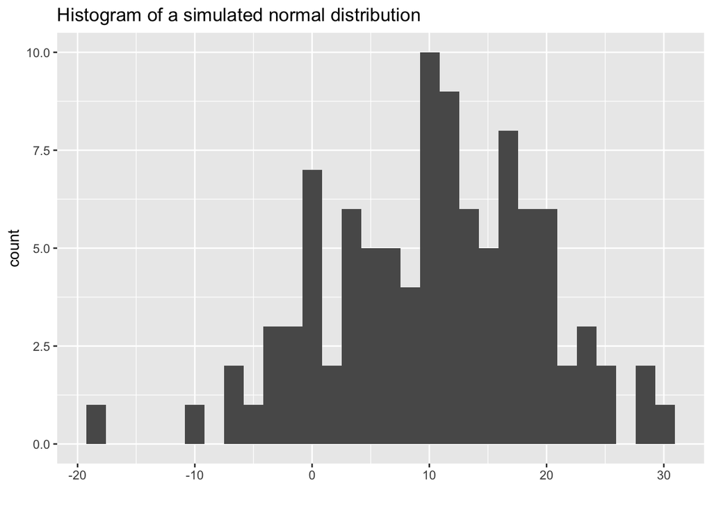

```r
as.data.frame(data1a) |> ggplot(aes(x = data1a)) +
  geom_histogram(bins = 30) +
  labs(title = "Histogram of a simulated normal distribution",
       x = "")
```

**Reproducible RNG**

Setting the seed in random number generation is crucial for reproducibility. By using `set.seed` with a specific value, such as the unit code or your student number, you ensure that the sequence of random numbers generated is the same each time the code is run. This is particularly important in **your group project**, where reproducibility of results is essential. By resetting the seed to the same value, you can generate identical ‘random’ samples, which allows for consistent and verifiable results. Let’s use `set.seed(5003)` to complete the rest of the workshop.

**Log likelihood**

Recall the log likelihood for a sample of $n$ iid normal variables $(x_1..x_n)$ is as follows:

$$\begin{align*}
L(\boldsymbol{\theta}; \boldsymbol{x}) &= \log \left( \prod_{i = 1}^{n} \left(\sqrt{2\pi \sigma^2}\right)^{-1} \exp\left(- \frac{(x_i - \mu)^2}{2\sigma^2}\right) \right) \\
&= -\frac{n}{2} \log \left( 2 \pi \sigma^2 \right) - \frac{1}{2\sigma^2} \sum_{i = 1}^{n} (x_i - \mu)^2
\end{align*}$$

1. Generate 100 observations are drawn from a normal distribution parameterised as N$(\mu = 10, \sigma = 10)$?
2. Using the generated data, calculate the log likelihood for varying values of $\mu$ from 1 to 20, while keeping $\sigma = 10$.
3. Plot the log likelihood against $\mu$. From the plot, determine the maximum likelihood estimate of $\mu$?

```r
set.seed(5003)

data.1c <- rnorm(100, 10, 10)
mu <- 1:20

## define a function to calculate the loglikelihood
log.likelihood <- function(mu, sigma, x) {
  n <- length(x)
  -n/2 * log(2 * pi * sigma^2) - 1/(2 * sigma^2) * sum((x - mu)^2)
}


# Initialise a vector to store the results
log_likelihood_results <- rep(0, length(mu))

# Loop to calculate the log-likelihood for each value of mu
for (i in mu) {
  log_likelihood_results[i] <- log.likelihood(mu[i], 10, data.1c)
}

# Print the results
print(log_likelihood_results)
```

```
 [1] -426.2357 -416.3352 -407.4347 -399.5342 -392.6336 -386.7331 -381.8326
 [8] -377.9321 -375.0316 -373.1311 -372.2306 -372.3300 -373.4295 -375.5290
[15] -378.6285 -382.7280 -387.8275 -393.9270 -401.0264 -409.1259
```

```r
plot(mu, log_likelihood_results, type = "l", ylab = "Log Likelihood")
mu.mle <- mu[which.max(log_likelihood_results)]
mu.mle
```

```
[1] 11
```

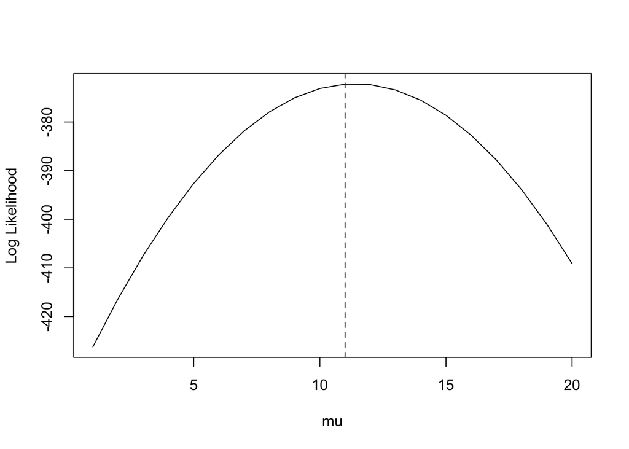

```r
abline(v = mu.mle, lty = 2)
```

## 3.1 Parametric and Non-Parametric Density Estimation

**Basic Exploratory Data Analysis**

For this question, we will be performing density estimates on the heights dataset. Load the `height.csv` into a data frame. Make a histogram of the heights, set the y axis to be probability not frequency. Repeat for 5, 10, and 20 bins.

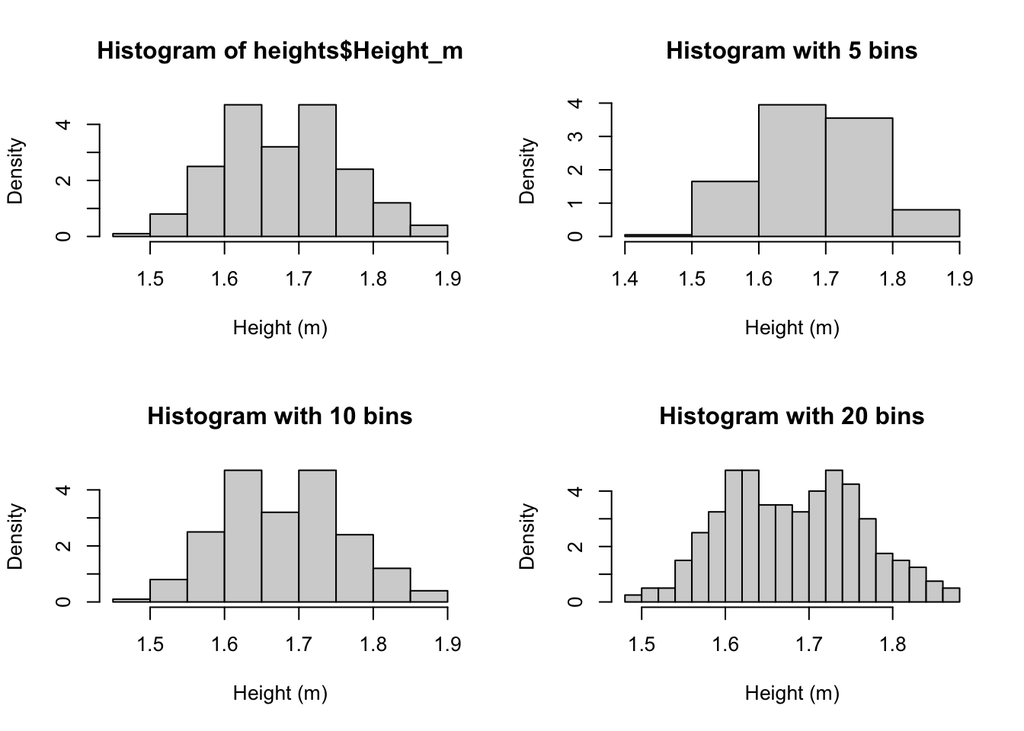

```r
# Load the dataset
heights <- read.csv(here("datasets", "height.csv"))

# Create a 2x2 plotting grid
par(mfrow = c(2, 2))

# Plot the first histogram
hist(heights$Height_m, probability = TRUE, xlab = "Height (m)")

# Define the number of bins
n_bins <- c(5, 10, 20)

# Plot histograms with different numbers of bins
for (n in n_bins) {
  hist(heights$Height_m, probability = TRUE, breaks = n,
       xlab = "Height (m)",
       main = paste("Histogram with", n, "bins"))
}
```

**Kernel Density Estimation**

Use the `density` function to perform kernel density estimation with the Gaussian, the Epanechnikov, and the triangular kernels. Plot the results for each kernel. An example for the `Gaussian` kernel is provided for you (next slide). Expanding the kernels vector to contain all three kernels and plotting them via a loop.

**Kernel Density Estimation**

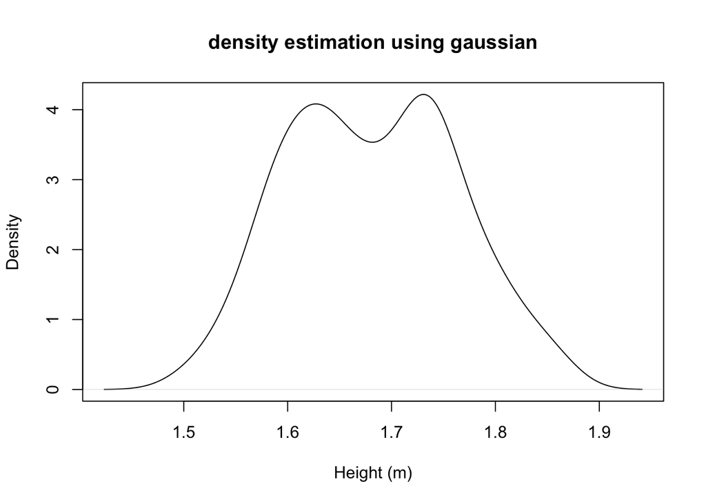

```r
kernels <- c("gaussian")

 plot(density(heights$Height_m, kernel = paste(kernels)),
       xlab = "Height (m)",
       main = paste("density estimation using", kernels ))
```

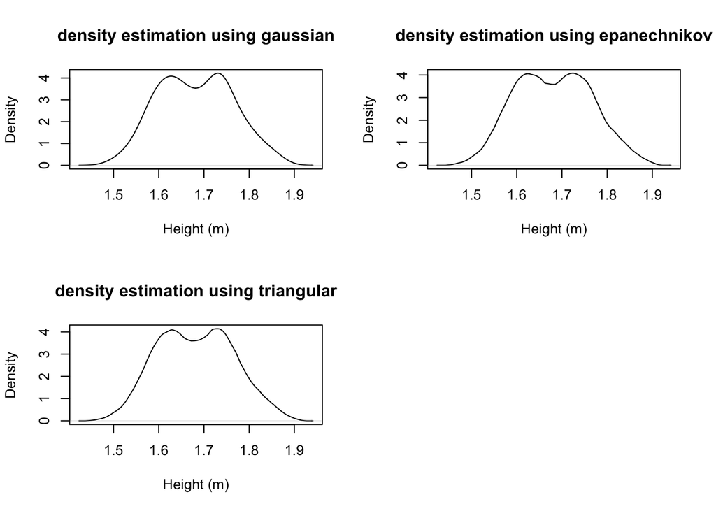

```r
kernels <- c("gaussian", "epanechnikov", "triangular")
par(mfrow = c(2, 2))

# density estimation using different kernels
for (n in kernels) {
  plot(density(heights$Height_m, kernel = n),
       xlab = "Height (m)",
       main = paste("density estimation using", n ))
}
```

**Probability Calculation**

Compute an estimate of the probability that a person is taller than 1.7m using a kernel density estimator.

```r
# Use the approximate and integrate functions
density.est <- density(heights$Height_m)
#?approxfun
f <- approxfun(density.est)
prob <- integrate(f, 1.7, max(density.est$x))
prob
```

```
0.4310232 with absolute error < 3.2e-05
```

**Maximum Likelihood Estimation**

If we assume the heights data follows a Gaussian distribution, what are the maximum likelihood estimates of the mean $\mu$ and standard deviation $\sigma$? *Hint*: See `?mle` from the `stats4` library.

```r
library(stats4)

## type "?mle" to see the components required to run this function

## write a function that calculates the negative log-likelihood for the data
negativelogLikelihood <- function(m, s) {
    if (s < 0)
        return(Inf)
    -sum(log(dnorm(heights$Height_m, mean = m, sd = s)))
}
mle.fit <- mle(negativelogLikelihood, list(m = 1, s = 1)) ## list contains the starting values for the mean and the standard deviation
mle.fit
```

```
Call:
mle(minuslogl = negativelogLikelihood, start = list(m = 1, s = 1))

Coefficients:
         m          s
1.68177704 0.08083764
```

```r
summary(mle.fit)
```

```
Maximum likelihood estimation

Call:
mle(minuslogl = negativelogLikelihood, start = list(m = 1, s = 1))

Coefficients:
    Estimate  Std. Error
m 1.68177704 0.005716084
s 0.08083764 0.004039514

-2 log L: -438.577
```

## 3.2 Bandwidth Selection

**Integrated Sqaure Error**

**The Integrated Square Error** is a performance metric used to assess the accuracy of density estimates. It quantifies the discrepancy between the estimated density and the true density function.

$\text{ISE}(h) = \int_{-\infty}^\infty (\widehat f(x;h) - f(x))^2\, dx$

**Determining the Optimal Bandwidth for Density Estimation**

Evaluate the following code chunk to determine how these codes are applied to find the optimal bandwidth needed for the density function:

```r
# Set seed for reproducibility
set.seed(5003)

# Generate data
z <- rnorm(100)

# Define the grid for bandwidth values
h.grid <- seq(from = 0.01, to = 1, length.out = 256)

# Initialize a list to store density estimates
density.estimates <- vector("list", length(h.grid))

# Calculate density estimates using a loop
for (i in 1: length(h.grid)) {
  h <- h.grid[i]
  density.estimates[[i]] <- density(z, bw = h, n = 512, from = -3, to = 3)
}

# Define the ISE function
ise <- function(f, fhat) mean((fhat - f)^2) * 6 # recall we choose -3 to 3 to evaluate the integral

# Initialize a vector to store ISE values
ise.h <- rep(0, length(h.grid))

# Calculate ISE values using a loop
for (i in 1: length(density.estimates)) {
  d <- density.estimates[[i]]
  ise.h[i] <- ise(dnorm(d$x), d$y)
}

# Plot the ISE against bandwidth
par(mfrow = c(1, 2))
plot(h.grid, ise.h, type = "l", main = "ISE(h)",
     xlab = "Bandwidth (h)", ylab = "ISE")

# Find the optimal bandwidth
opt.ind <- which.min(ise.h)
opt.h <- h.grid[opt.ind]

# Plot the density estimate with the optimal bandwidth
plot(density.estimates[[opt.ind]], main = "",
     xlab = "", ylab = "Density", ylim = c(-1e-2, dnorm(0) + 1e-2))
rug(z)
legend("topright", legend = c("Estimated via KDE",
                              "Standard Normal Density"),
       col = 1:2, lty = 1:2)
x <- density.estimates[[1]]$x
lines(x, dnorm(x), lty = 2, col = 2)
```

**Determining the Optimal Bandwidth for Density Estimation**

Based on the left graph, consider the relationship between the Integrated Squared Error (ISE) and the bandwidth in kernel density estimation. How does the bias-variance trade-off influence this relationship?

[figure not shown]

The key takeaway is that small values of `h` (bandwidth) make the estimate look “wiggly” and show spurious features (low bias but high variance) whereas too big values of `h` will lead to an estimate which is too smooth in the sense that it is too biased (high bias but low variance). This demonstrates the concept of variance-bias tradeoff and for more info refer to Chapter 2.2 in the Intro to Statistiscal Learning textbook.